# Кардиотокография

Кардиотокография — диагностическая техника, фиксирующая сердцебиение плода и тонус матки и позволяющая оценить состояние эмбриона. Непосредственный результат наблюдений интерпретировать крайне сложно. Чтобы облегчить задачу диагностики, результаты кардиотокографии 1831 эмбрионов были классифицированы опытными специалистами на нормальные и патологические, а на основе показаний прибора было сгенерировано 22 признака. Ставится задача построения функции, определяющей вероятность наличия патологии по описанию кардиотокограммы и оценки вклада признаков.

Посмотрим на распределения непрерывных признаков в классах:

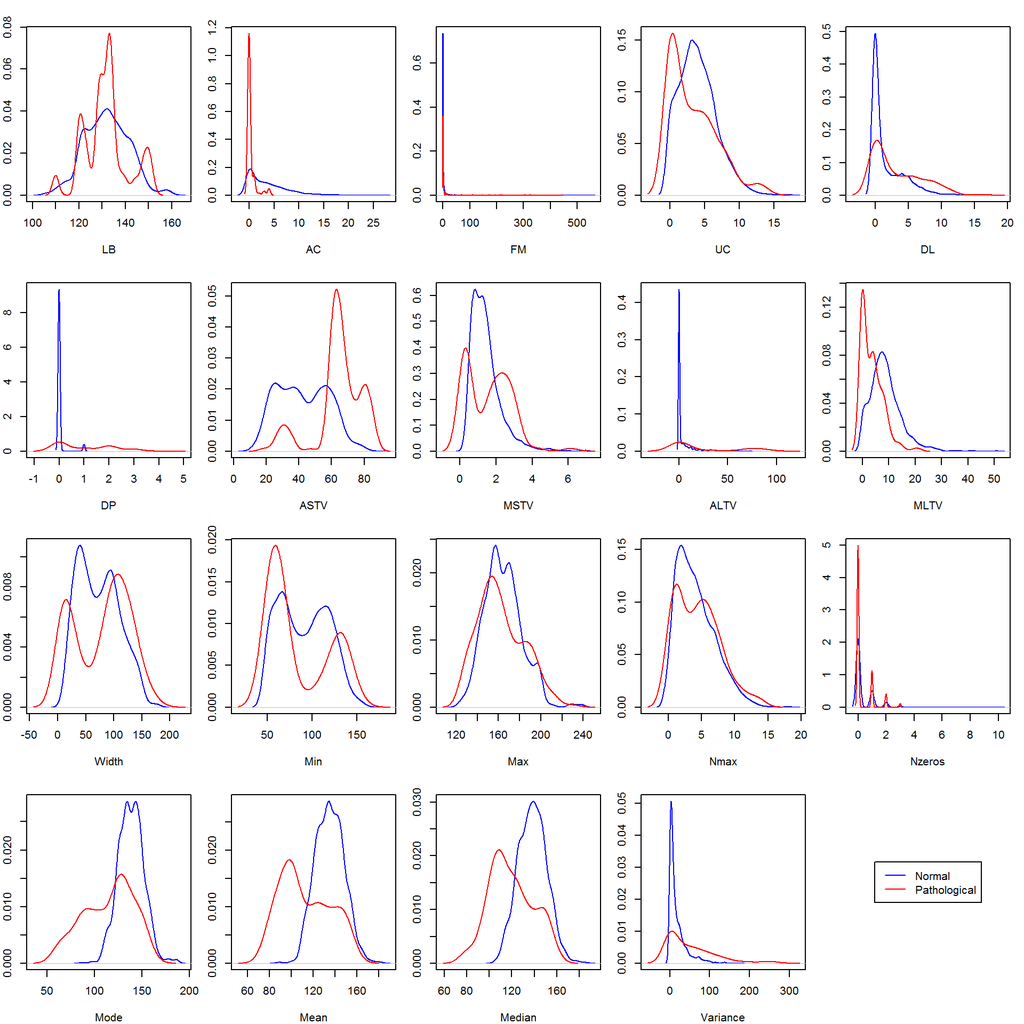

Линейной разделимости по отдельным признакам нет.

Посмотрим на таблицы сопряжённости по категориальным признакам:

```r
table(data$DS, data$NSP)
```

```
##
##        N    P
##   0 1654  170
##   1    1    6
```

```r
table(data$DR, data$NSP)
```

```
##
##        N    P
##   0 1655  176
```

```r
table(data$Tendency, data$NSP)
```

```
##
##        N   P
##   0  887  91
##   1  667  36
##   -1 101  49
```

DR — константа, DS — почти константа, поэтому удалим эти признаки.

Для предварительного отбора признаков построим одномерные модели по каждому фактору и оценим их значимость:

```
## Single term additions
##
## Model:
## NSP ~ 1
##          Df Deviance     AIC    LRT  Pr(>Chi)
## <none>       1158.94 1160.94
## LB        1  1158.79 1162.79   0.15 0.6942085
## AC        1   936.86  940.86 222.09 < 2.2e-16 ***
## FM        1  1152.07 1156.07   6.87 0.0087488 **
## UC        1  1147.54 1151.54  11.40 0.0007333 ***
## DL        1  1112.55 1116.55  46.39 9.673e-12 ***
## DP        1   786.09  790.09 372.86 < 2.2e-16 ***
## ASTV      1   846.11  850.11 312.83 < 2.2e-16 ***
## MSTV      1  1154.75 1158.75   4.19 0.0406891 *
## ALTV      1  1034.02 1038.02 124.92 < 2.2e-16 ***
## MLTV      1   986.78  990.78 172.17 < 2.2e-16 ***
## Width     1  1156.23 1160.23   2.71 0.0996995 .
## Min       1  1148.54 1152.54  10.41 0.0012544 **
## Max       1  1156.66 1160.66   2.28 0.1310242
## Nmax      1  1157.50 1161.50   1.45 0.2289213
## Nzeros    1  1158.90 1162.90   0.04 0.8380699
## Mode      1   883.20  887.20 275.74 < 2.2e-16 ***
## Mean      1   863.66  867.66 295.28 < 2.2e-16 ***
## Median    1   894.20  898.20 264.74 < 2.2e-16 ***
## Variance  1  1028.10 1032.10 130.85 < 2.2e-16 ***
## Tendency  2  1079.08 1085.08  79.87 < 2.2e-16 ***
## ---
## Signif. codes:  0 '***' 0.001 '**' 0.01 '*' 0.05 '.' 0.1 ' ' 1
```

#### Модель 1

Многомерная модель со всеми предикторами, значимыми на уровне 0.25:

```
##
## Call:
## glm(formula = NSP ~ AC + FM + UC + DL + DP + ASTV + MSTV + ALTV +
##     MLTV + Width + Min + Max + Nmax + Mode + Mean + Median +
##     Variance + Tendency, family = binomial(), data = data)
##
## Deviance Residuals:
##      Min        1Q    Median        3Q       Max
## -2.44082  -0.01291  -0.00081  -0.00001   2.96869
##
## Coefficients: (1 not defined because of singularities)
##              Estimate Std. Error z value Pr(>|z|)
## (Intercept) -7.627845   4.162456  -1.833 0.066872 .
## AC          -2.064428   0.406195  -5.082 3.73e-07 ***
## FM           0.007405   0.011112   0.666 0.505130
## UC          -0.784745   0.137778  -5.696 1.23e-08 ***
## DL           0.182245   0.167896   1.085 0.277717
## DP           5.184288   0.862469   6.011 1.84e-09 ***
## ASTV         0.175434   0.026587   6.599 4.15e-11 ***
## MSTV        -0.782004   0.718831  -1.088 0.276647
## ALTV         0.087209   0.015510   5.623 1.88e-08 ***
## MLTV         0.095381   0.088700   1.075 0.282232
## Width        0.113976   0.024947   4.569 4.91e-06 ***
## Min          0.131639   0.036289   3.628 0.000286 ***
## Max                NA         NA      NA       NA
## Nmax        -0.568427   0.188824  -3.010 0.002609 **
## Mode        -0.122634   0.053454  -2.294 0.021779 *
## Mean        -0.006332   0.068051  -0.093 0.925865
## Median      -0.057577   0.070480  -0.817 0.413970
## Variance     0.082813   0.016206   5.110 3.22e-07 ***
## Tendency1    1.385410   0.729785   1.898 0.057646 .
## Tendency-1  -2.185038   0.931064  -2.347 0.018935 *
## ---
## Signif. codes:  0 '***' 0.001 '**' 0.01 '*' 0.05 '.' 0.1 ' ' 1
##
## (Dispersion parameter for binomial family taken to be 1)
##
##     Null deviance: 1158.94  on 1830  degrees of freedom
## Residual deviance:  127.74  on 1812  degrees of freedom
## AIC: 165.74
##
## Number of Fisher Scoring iterations: 11
```

Один из коэффициентов не определяется, значит, среди признаков есть линейно зависимые. Попробуем удалять по одному признаку, чтобы посмотреть, в каком случае линейная зависимость исчезает. В следующей таблице содержатся коэффициенты таких моделей, по строкам — признаки, которые в модели есть, по столбцам — признаки, удалённые из модели.

```
##                AC     FM     UC     DL     DP   ASTV   MSTV   ALTV   MLTV
## AC          0.000 -2.089 -1.943 -2.058 -1.521 -1.791 -2.000 -1.971 -2.044
## FM          0.004  0.000  0.020  0.007  0.021  0.007  0.008  0.020  0.013
## UC         -0.700 -0.799  0.000 -0.761 -0.469 -0.707 -0.767 -0.776 -0.777
## DL          0.189  0.180 -0.009  0.000 -0.062  0.367  0.170 -0.097  0.149
## DP          4.904  5.410  3.772  5.105  0.000  5.409  4.920  4.093  4.925
## ASTV        0.160  0.174  0.173  0.178  0.176  0.000  0.182  0.171  0.173
## MSTV       -0.448 -0.876 -0.328 -0.755 -0.214 -2.760  0.000 -1.228 -0.767
## ALTV        0.087  0.089  0.078  0.084  0.059  0.076  0.087  0.000  0.082
## MLTV        0.075  0.126  0.067  0.078 -0.021  0.007  0.071 -0.169  0.000
## Width       0.061  0.114  0.092  0.117  0.072  0.116  0.104  0.098  0.116
## Min         0.076  0.137  0.102  0.130  0.076  0.156  0.117  0.118  0.126
## Max            NA     NA     NA     NA     NA     NA     NA     NA     NA
## Nmax       -0.452 -0.533 -0.356 -0.532 -0.278 -0.605 -0.570 -0.402 -0.584
## Mode       -0.078 -0.126 -0.119 -0.116 -0.069 -0.071 -0.130 -0.127 -0.125
## Mean        0.073 -0.019  0.043 -0.020 -0.047 -0.168  0.045  0.019  0.013
## Median     -0.157 -0.047 -0.044 -0.057 -0.104  0.034 -0.078 -0.059 -0.067
## Variance    0.063  0.087  0.071  0.082  0.067  0.054  0.077  0.075  0.078
## Tendency1   1.393  1.418  1.034  1.236  1.336  1.969  1.285  1.427  1.399
## Tendency-1 -1.649 -2.243 -1.497 -2.350 -1.878 -1.086 -2.146 -1.846 -2.243
##             Width    Min    Max   Nmax   Mode   Mean Median Variance
## AC         -2.064 -2.064 -2.064 -1.943 -1.952 -2.057 -2.155   -1.608
## FM          0.007  0.007  0.007  0.008  0.009  0.008  0.006    0.014
## UC         -0.785 -0.785 -0.785 -0.714 -0.795 -0.783 -0.786   -0.694
## DL          0.182  0.182  0.182  0.105  0.147  0.185  0.185    0.144
## DP          5.184  5.184  5.184  4.679  4.985  5.159  5.432    4.770
## ASTV        0.175  0.175  0.175  0.181  0.167  0.176  0.175    0.141
## MSTV       -0.782 -0.782 -0.782 -0.741 -0.856 -0.736 -1.019    0.409
## ALTV        0.087  0.087  0.087  0.082  0.086  0.087  0.088    0.077
## MLTV        0.095  0.095  0.095  0.122  0.113  0.092  0.109   -0.018
## Width       0.000 -0.018  0.114  0.086  0.116  0.113  0.111    0.113
## Min         0.018  0.000  0.132  0.122  0.137  0.131  0.128    0.112
## Max         0.114  0.132  0.000     NA     NA     NA     NA       NA
## Nmax       -0.568 -0.568 -0.568  0.000 -0.567 -0.566 -0.599   -0.587
## Mode       -0.123 -0.123 -0.123 -0.121  0.000 -0.124 -0.147   -0.105
## Mean       -0.006 -0.006 -0.006  0.028 -0.045  0.000 -0.037    0.034
## Median     -0.058 -0.058 -0.058 -0.086 -0.157 -0.061  0.000   -0.101
## Variance    0.083  0.083  0.083  0.083  0.076  0.083  0.086    0.000
## Tendency1   1.385  1.385  1.385  1.407  1.333  1.376  1.329    1.862
## Tendency-1 -2.185 -2.185 -2.185 -2.190 -1.726 -2.185 -2.090   -2.049
##            Tendency
## AC           -1.974
## FM            0.009
## UC           -0.747
## DL            0.195
## DP            5.046
## ASTV          0.177
## MSTV         -0.605
## ALTV          0.081
## MLTV          0.088
## Width         0.076
## Min           0.066
## Max              NA
## Nmax         -0.569
## Mode         -0.093
## Mean          0.008
## Median       -0.027
## Variance      0.081
## Tendency1     0.000
## Tendency-1    0.000
```

По всей видимости, коллинеарны признаки в группе Width, Min и Max — при удалении любого из них получается хорошая модель, причём одна и та же.

#### Модель 2

Удалим Width:

```
##
## Call:
## glm(formula = NSP ~ AC + FM + UC + DL + DP + ASTV + MSTV + ALTV +
##     MLTV + Min + Max + Nmax + Mode + Mean + Median + Variance +
##     Tendency, family = binomial(), data = data)
##
## Deviance Residuals:
##      Min        1Q    Median        3Q       Max
## -2.44082  -0.01291  -0.00081  -0.00001   2.96869
##
## Coefficients:
##              Estimate Std. Error z value Pr(>|z|)
## (Intercept) -7.627845   4.162456  -1.833  0.06687 .
## AC          -2.064428   0.406195  -5.082 3.73e-07 ***
## FM           0.007405   0.011112   0.666  0.50513
## UC          -0.784745   0.137778  -5.696 1.23e-08 ***
## DL           0.182245   0.167896   1.085  0.27772
## DP           5.184288   0.862469   6.011 1.84e-09 ***
## ASTV         0.175434   0.026587   6.599 4.15e-11 ***
## MSTV        -0.782004   0.718831  -1.088  0.27665
## ALTV         0.087209   0.015510   5.623 1.88e-08 ***
## MLTV         0.095381   0.088700   1.075  0.28223
## Min          0.017663   0.020749   0.851  0.39462
## Max          0.113976   0.024947   4.569 4.91e-06 ***
## Nmax        -0.568427   0.188824  -3.010  0.00261 **
## Mode        -0.122634   0.053454  -2.294  0.02178 *
## Mean        -0.006332   0.068051  -0.093  0.92586
## Median      -0.057577   0.070480  -0.817  0.41397
## Variance     0.082813   0.016206   5.110 3.22e-07 ***
## Tendency1    1.385410   0.729785   1.898  0.05765 .
## Tendency-1  -2.185038   0.931064  -2.347  0.01893 *
## ---
## Signif. codes:  0 '***' 0.001 '**' 0.01 '*' 0.05 '.' 0.1 ' ' 1
##
## (Dispersion parameter for binomial family taken to be 1)
##
##     Null deviance: 1158.94  on 1830  degrees of freedom
## Residual deviance:  127.74  on 1812  degrees of freedom
## AIC: 165.74
##
## Number of Fisher Scoring iterations: 11
```

Критерий отношения правдоподобия считает такую модель существенно лучшей константы:

```
## Likelihood ratio test
##
## Model 1: NSP ~ 1
## Model 2: NSP ~ AC + FM + UC + DL + DP + ASTV + MSTV + ALTV + MLTV + Min +
##     Max + Nmax + Mode + Mean + Median + Variance + Tendency
##   #Df  LogLik Df  Chisq Pr(>Chisq)
## 1   1 -579.47
## 2  19  -63.87 18 1031.2  < 2.2e-16 ***
## ---
## Signif. codes:  0 '***' 0.001 '**' 0.01 '*' 0.05 '.' 0.1 ' ' 1
```

#### Модели 3 и 4

Новая модель без незначимых признаков:

```
##
## Call:
## glm(formula = NSP ~ AC + UC + DP + ASTV + ALTV + Max + Nmax +
##     Mode + Variance + Tendency, family = binomial(), data = data)
##
## Deviance Residuals:
##      Min        1Q    Median        3Q       Max
## -2.42659  -0.01493  -0.00101  -0.00002   3.00055
##
## Coefficients:
##             Estimate Std. Error z value Pr(>|z|)
## (Intercept) -7.25950    3.13943  -2.312 0.020758 *
## AC          -2.00788    0.35935  -5.588 2.30e-08 ***
## UC          -0.77251    0.12816  -6.028 1.66e-09 ***
## DP           4.94443    0.73791   6.701 2.08e-11 ***
## ASTV         0.17051    0.02320   7.349 2.00e-13 ***
## ALTV         0.08139    0.01333   6.104 1.03e-09 ***
## Max          0.09367    0.02013   4.654 3.25e-06 ***
## Nmax        -0.56169    0.14506  -3.872 0.000108 ***
## Mode        -0.14599    0.02513  -5.810 6.24e-09 ***
## Variance     0.07331    0.01283   5.713 1.11e-08 ***
## Tendency1    0.94780    0.60131   1.576 0.114973
## Tendency-1  -2.09430    0.83118  -2.520 0.011746 *
## ---
## Signif. codes:  0 '***' 0.001 '**' 0.01 '*' 0.05 '.' 0.1 ' ' 1
##
## (Dispersion parameter for binomial family taken to be 1)
##
##     Null deviance: 1158.9  on 1830  degrees of freedom
## Residual deviance:  135.4  on 1819  degrees of freedom
## AIC: 159.4
##
## Number of Fisher Scoring iterations: 11
```

```
## Likelihood ratio test
##
## Model 1: NSP ~ AC + UC + DP + ASTV + ALTV + Max + Nmax + Mode + Variance +
##     Tendency
## Model 2: NSP ~ AC + FM + UC + DL + DP + ASTV + MSTV + ALTV + MLTV + Min +
##     Max + Nmax + Mode + Mean + Median + Variance + Tendency
##   #Df  LogLik Df  Chisq Pr(>Chisq)
## 1  12 -67.700
## 2  19 -63.869  7 7.6622     0.3633
```

По критерию отношения правдоподобия ухудшения не произошло. В полученной модели значимы все признаки, кроме фиктивной переменной для Tendency=1.

Проверим линейность логита по непрерывным признакам. Сглаженные диаграммы рассеяния:

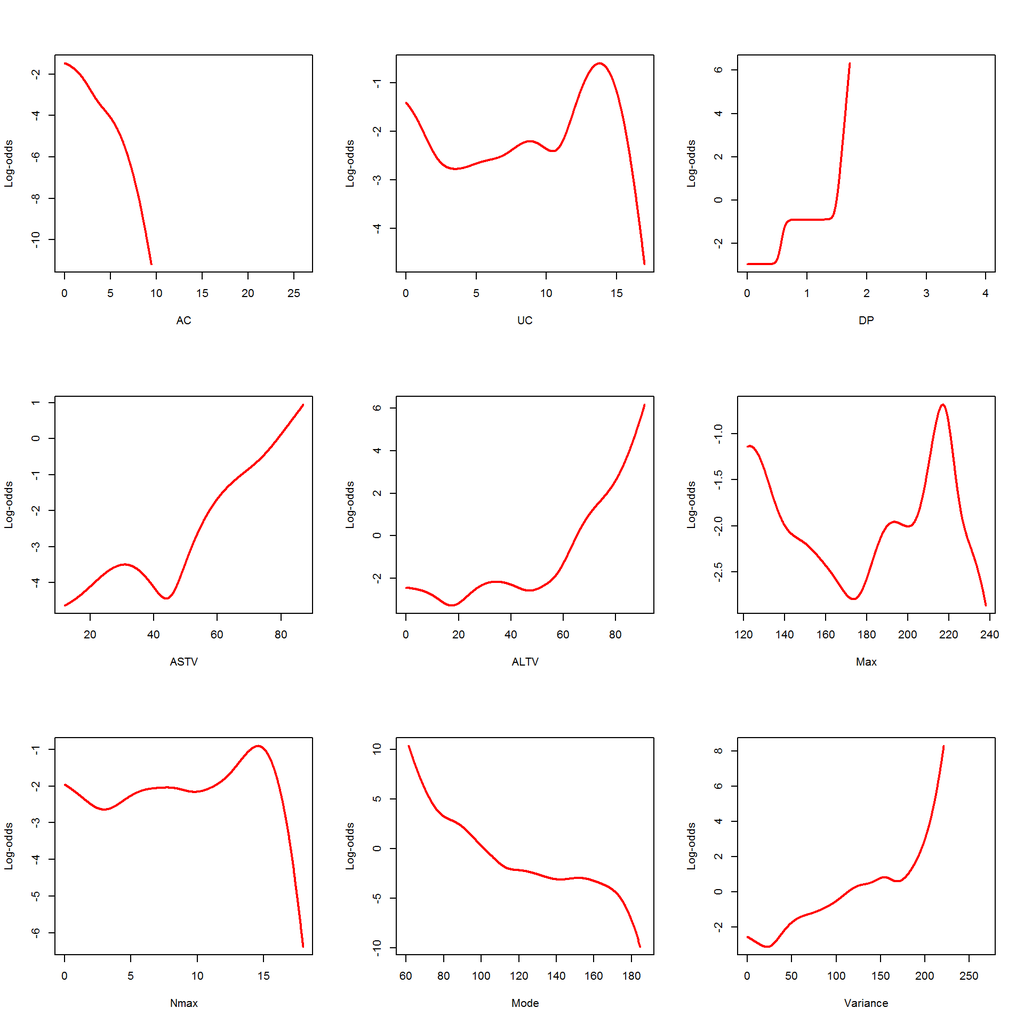

По некоторым признакам логит существенно нелинеен. Попробуем подобрать дробные полиномы для непрерывных признаков:

```
## Call:
## mfp(formula = NSP ~ fp(AC) + fp(UC) + fp(DP) + fp(ASTV) + fp(ALTV) +
##     fp(Max) + fp(Nmax) + fp(Mode) + fp(Variance) + Tendency,
##     data = data, family = binomial)
##
##
## Deviance table:
##           Resid. Dev
## Null model    1158.944
## Linear model  135.401
## Final model   104.2143
##
## Fractional polynomials:
##            df.initial select alpha df.final power1 power2
## ASTV                4      1  0.05        1      1      .
## DP                  4      1  0.05        1      1      .
## ALTV                4      1  0.05        2      3      .
## UC                  4      1  0.05        1      1      .
## Mode                4      1  0.05        1      1      .
## AC                  4      1  0.05        1      1      .
## Variance            4      1  0.05        1      1      .
## Max                 4      1  0.05        4      3      3
## Nmax                4      1  0.05        2      0      .
## Tendency1           1      1  0.05        1      1      .
## Tendency-1          1      1  0.05        1      1      .
##
##
## Transformations of covariates:
##                                               formula
## AC                                   I(((AC+1)/10)^1)
## UC                                   I(((UC+1)/10)^1)
## DP                                        I((DP+1)^1)
## ASTV                                  I((ASTV/100)^1)
## ALTV                               I(((ALTV+1)/10)^3)
## Max      I((Max/100)^3)+I((Max/100)^3*log((Max/100)))
## Nmax                               log(((Nmax+1)/10))
## Mode                                  I((Mode/100)^1)
## Variance                       I(((Variance+1)/10)^1)
## Tendency                                     Tendency
##
## Re-Scaling:
## Non-positive values in some of the covariates. No re-scaling was performed.
##
## Coefficients:
##    Intercept        ASTV.1          DP.1        ALTV.1          UC.1
##    -20.87666      21.28934       4.70903       0.01877      -7.64519
##       Mode.1          AC.1    Variance.1         Max.1         Max.2
##    -21.15574     -27.87257       0.70849      13.22180     -12.99333
##       Nmax.1   Tendency1.1  Tendency-1.1
##     -3.38436       1.83937      -1.85086
##
## Degrees of Freedom: 1830 Total (i.e. Null);  1818 Residual
## Null Deviance:       1159
## Residual Deviance: 104.2     AIC: 130.2
```

```
##
## Call:
## glm(formula = NSP ~ AC + UC + DP + ASTV + I(ALTV^3) + I(Max^3 *
##     (1 + log(Max))) + log(Nmax + 1) + Mode + Variance + Tendency,
##     family = binomial(), data = data)
##
## Deviance Residuals:
##     Min       1Q   Median       3Q      Max
## -2.5137  -0.0209  -0.0017   0.0000   3.2647
##
## Coefficients:
##                             Estimate Std. Error z value Pr(>|z|)
## (Intercept)                2.180e-02  2.559e+00   0.009 0.993202
## AC                        -1.774e+00  3.295e-01  -5.383 7.32e-08 ***
## UC                        -7.167e-01  1.296e-01  -5.532 3.16e-08 ***
## DP                         4.505e+00  6.858e-01   6.569 5.08e-11 ***
## ASTV                       1.694e-01  2.369e-02   7.150 8.69e-13 ***
## I(ALTV^3)                  1.319e-05  2.102e-06   6.275 3.51e-10 ***
## I(Max^3 * (1 + log(Max)))  8.983e-08  2.700e-08   3.327 0.000878 ***
## log(Nmax + 1)             -1.944e+00  5.357e-01  -3.628 0.000285 ***
## Mode                      -9.613e-02  1.940e-02  -4.954 7.26e-07 ***
## Variance                   7.118e-02  1.250e-02   5.693 1.25e-08 ***
## Tendency1                  4.560e-01  5.850e-01   0.779 0.435711
## Tendency-1                -7.659e-01  7.405e-01  -1.034 0.300966
## ---
## Signif. codes:  0 '***' 0.001 '**' 0.01 '*' 0.05 '.' 0.1 ' ' 1
##
## (Dispersion parameter for binomial family taken to be 1)
##
##     Null deviance: 1158.9  on 1830  degrees of freedom
## Residual deviance:  139.1  on 1819  degrees of freedom
## AIC: 163.1
##
## Number of Fisher Scoring iterations: 11
```

У модели с преобразованными признаками большая аномальность, то есть, она хуже объясняет выборку. Посмотрим на сглаженные диаграммы рассеяния для преобразованных признаков:

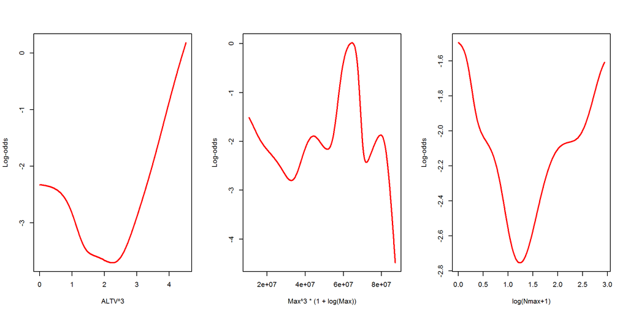

Видим, что ни по одному из признаков логит не стал линейнее. Откажемся от найденных преобразований.

#### Модели 5 и 6

Попробуем добавлять в линейную модель попарные взаимодействия:

```
## Single term additions
##
## Model:
## NSP ~ AC + UC + DP + ASTV + ALTV + Max + Nmax + Mode + Variance +
##     Tendency
##                   Df Deviance    AIC     LRT  Pr(>Chi)
## <none>                 135.40 159.40
## AC:UC              1   129.70 155.70  5.7024 0.0169413 *
## AC:DP              1   133.63 159.63  1.7752 0.1827377
## AC:ASTV            1   135.01 161.01  0.3947 0.5298456
## AC:ALTV            1   133.78 159.78  1.6193 0.2031865
## AC:Max             1   135.36 161.36  0.0409 0.8397129
## AC:Nmax            1   135.33 161.33  0.0668 0.7960725
## AC:Mode            1   130.03 156.03  5.3683 0.0205054 *
## AC:Variance        1   134.81 160.81  0.5945 0.4406819
## AC:Tendency        2   131.77 159.77  3.6326 0.1626235
## UC:DP              1   135.20 161.20  0.1968 0.6572779
## UC:ASTV            1   123.56 149.56 11.8407 0.0005795 ***
## UC:ALTV            1   127.07 153.07  8.3313 0.0038967 **
## UC:Max             1   134.11 160.11  1.2904 0.2559679
## UC:Nmax            1   128.78 154.78  6.6262 0.0100489 *
## UC:Mode            1   122.22 148.22 13.1822 0.0002826 ***
## UC:Variance        1   118.04 144.04 17.3573 3.097e-05 ***
## UC:Tendency        2   134.93 162.93  0.4717 0.7898822
## DP:ASTV            1   130.08 156.08  5.3169 0.0211197 *
## DP:ALTV            1   134.61 160.61  0.7940 0.3728982
## DP:Max             1   133.24 159.24  2.1588 0.1417541
## DP:Nmax            1   132.03 158.03  3.3742 0.0662254 .
## DP:Mode            1   126.09 152.09  9.3090 0.0022803 **
## DP:Variance        1   135.21 161.21  0.1910 0.6620837
## DP:Tendency        2   129.80 157.80  5.5984 0.0608577 .
## ASTV:ALTV          1   134.78 160.78  0.6155 0.4327184
## ASTV:Max           1   133.94 159.94  1.4649 0.2261584
## ASTV:Nmax          1   134.25 160.25  1.1539 0.2827384
## ASTV:Mode          1   133.99 159.99  1.4112 0.2348538
## ASTV:Variance      1   135.27 161.27  0.1337 0.7145815
## ASTV:Tendency      2   119.66 147.66 15.7436 0.0003814 ***
## ALTV:Max           1   131.12 157.12  4.2800 0.0385640 *
## ALTV:Nmax          1   134.03 160.03  1.3742 0.2410948
## ALTV:Mode          1   124.70 150.70 10.6989 0.0010720 **
## ALTV:Variance      1   131.58 157.58  3.8231 0.0505498 .
## ALTV:Tendency      2   129.49 157.49  5.9113 0.0520444 .
## Max:Nmax           1   130.13 156.13  5.2698 0.0216983 *
## Max:Mode           1   135.40 161.40  0.0013 0.9716904
## Max:Variance       1   132.32 158.32  3.0780 0.0793570 .
## Max:Tendency       2   131.88 159.88  3.5239 0.1717100
## Nmax:Mode          1   131.48 157.48  3.9194 0.0477327 *
## Nmax:Variance      1   134.73 160.73  0.6718 0.4124110
## Nmax:Tendency      2   129.87 157.87  5.5327 0.0628925 .
## Mode:Variance      1   129.37 155.37  6.0323 0.0140466 *
## Mode:Tendency      2   129.46 157.46  5.9434 0.0512173 .
## Variance:Tendency  2   124.77 152.76 10.6355 0.0049037 **
## ---
## Signif. codes:  0 '***' 0.001 '**' 0.01 '*' 0.05 '.' 0.1 ' ' 1
```

Попробуем добавить несколько наиболее значимых (при этом для простоты не будем брать взаимодействия с категориальным признаком):

```
##
## Call:
## glm(formula = NSP ~ AC + UC + DP + ASTV + ALTV + Max + Nmax +
##     Mode + Variance + Tendency + UC:Mode + UC:Variance + UC:ASTV,
##     family = binomial(), data = data)
##
## Deviance Residuals:
##     Min       1Q   Median       3Q      Max
## -2.8185  -0.0097  -0.0005   0.0000   3.2071
##
## Coefficients:
##               Estimate Std. Error z value Pr(>|z|)
## (Intercept) -11.472021   4.656134  -2.464  0.01375 *
## AC           -2.283661   0.484133  -4.717 2.39e-06 ***
## UC            1.321322   1.080405   1.223  0.22133
## DP            4.661698   0.799059   5.834 5.41e-09 ***
## ASTV          0.203460   0.035368   5.753 8.79e-09 ***
## ALTV          0.082101   0.015623   5.255 1.48e-07 ***
## Max           0.066470   0.022763   2.920  0.00350 **
## Nmax         -0.345776   0.158414  -2.183  0.02905 *
## Mode         -0.096558   0.037419  -2.580  0.00987 **
## Variance      0.047408   0.023258   2.038  0.04151 *
## Tendency1     0.023782   0.677409   0.035  0.97199
## Tendency-1   -1.779207   0.945493  -1.882  0.05987 .
## UC:Mode      -0.013175   0.007413  -1.777  0.07553 .
## UC:Variance   0.009430   0.004660   2.023  0.04303 *
## UC:ASTV      -0.011232   0.009528  -1.179  0.23846
## ---
## Signif. codes:  0 '***' 0.001 '**' 0.01 '*' 0.05 '.' 0.1 ' ' 1
##
## (Dispersion parameter for binomial family taken to be 1)
##
##     Null deviance: 1158.94  on 1830  degrees of freedom
## Residual deviance:  112.69  on 1816  degrees of freedom
## AIC: 142.69
##
## Number of Fisher Scoring iterations: 11
```

```
## Likelihood ratio test
##
## Model 1: NSP ~ AC + UC + DP + ASTV + ALTV + Max + Nmax + Mode + Variance +
##     Tendency + UC:Mode + UC:Variance + UC:ASTV
## Model 2: NSP ~ AC + UC + DP + ASTV + ALTV + Max + Nmax + Mode + Variance +
##     Tendency
##   #Df  LogLik Df  Chisq Pr(>Chisq)
## 1  15 -56.343
## 2  12 -67.700 -3 22.714  4.632e-05 ***
## ---
## Signif. codes:  0 '***' 0.001 '**' 0.01 '*' 0.05 '.' 0.1 ' ' 1
```

По критерию отношения правдоподобия получается лучше, однако часть коэффициентов модели незначимы. Проверим, что можно безболезненно удалить:

```
## Single term deletions
##
## Model:
## NSP ~ AC + UC + DP + ASTV + ALTV + Max + Nmax + Mode + Variance +
##     Tendency + UC:Mode + UC:Variance + UC:ASTV
##             Df Deviance    AIC    LRT  Pr(>Chi)
## <none>           112.69 142.69
## AC           1   167.11 195.11 54.422 1.618e-13 ***
## DP           1   182.67 210.67 69.986 < 2.2e-16 ***
## ALTV         1   158.66 186.66 45.970 1.201e-11 ***
## Max          1   121.02 149.02  8.331  0.003898 **
## Nmax         1   117.70 145.70  5.014  0.025140 *
## Tendency     2   116.59 142.59  3.905  0.141916
## UC:Mode      1   116.02 144.02  3.332  0.067944 .
## UC:Variance  1   117.26 145.26  4.569  0.032547 *
## UC:ASTV      1   114.06 142.06  1.370  0.241753
## ---
## Signif. codes:  0 '***' 0.001 '**' 0.01 '*' 0.05 '.' 0.1 ' ' 1
```

Удалим UC*ASTV и Tendency:

```
##
## Call:
## glm(formula = NSP ~ AC + UC + DP + ASTV + ALTV + Max + Nmax +
##     Mode + Variance + UC:Mode + UC:Variance, family = binomial(),
##     data = data)
##
## Deviance Residuals:
##      Min        1Q    Median        3Q       Max
## -2.49934  -0.00955  -0.00034   0.00000   2.82222
##
## Coefficients:
##               Estimate Std. Error z value Pr(>|z|)
## (Intercept) -11.958412   4.138115  -2.890  0.00385 **
## AC           -2.514007   0.507546  -4.953 7.30e-07 ***
## UC            1.418467   0.975276   1.454  0.14583
## DP            4.520784   0.787537   5.740 9.44e-09 ***
## ASTV          0.172193   0.025309   6.804 1.02e-11 ***
## ALTV          0.070991   0.012957   5.479 4.28e-08 ***
## Max           0.044778   0.019302   2.320  0.02035 *
## Nmax         -0.308170   0.149797  -2.057  0.03966 *
## Mode         -0.054969   0.028849  -1.905  0.05673 .
## Variance      0.049421   0.022280   2.218  0.02654 *
## UC:Mode      -0.019173   0.007521  -2.549  0.01080 *
## UC:Variance   0.011006   0.004187   2.629  0.00857 **
## ---
## Signif. codes:  0 '***' 0.001 '**' 0.01 '*' 0.05 '.' 0.1 ' ' 1
##
## (Dispersion parameter for binomial family taken to be 1)
##
##     Null deviance: 1158.94  on 1830  degrees of freedom
## Residual deviance:  118.72  on 1819  degrees of freedom
## AIC: 142.72
##
## Number of Fisher Scoring iterations: 11
```

```
## Likelihood ratio test
##
## Model 1: NSP ~ AC + UC + DP + ASTV + ALTV + Max + Nmax + Mode + Variance +
##     Tendency + UC:Mode + UC:Variance + UC:ASTV
## Model 2: NSP ~ AC + UC + DP + ASTV + ALTV + Max + Nmax + Mode + Variance +
##     UC:Mode + UC:Variance
##   #Df  LogLik Df  Chisq Pr(>Chisq)
## 1  15 -56.343
## 2  12 -59.360 -3 6.0331       0.11
```

```
## Likelihood ratio test
##
## Model 1: NSP ~ AC + UC + DP + ASTV + ALTV + Max + Nmax + Mode + Variance +
##     UC:Mode + UC:Variance
## Model 2: NSP ~ AC + UC + DP + ASTV + ALTV + Max + Nmax + Mode + Variance +
##     Tendency
##   #Df LogLik Df  Chisq Pr(>Chisq)
## 1  12 -59.36
## 2  12 -67.70  0 16.681  < 2.2e-16 ***
## ---
## Signif. codes:  0 '***' 0.001 '**' 0.01 '*' 0.05 '.' 0.1 ' ' 1
```

Модель получается не хуже пятой и лучше третьей; остановимся на ней.

#### Модель 7

Попробуем удалить влиятельные наблюдения:

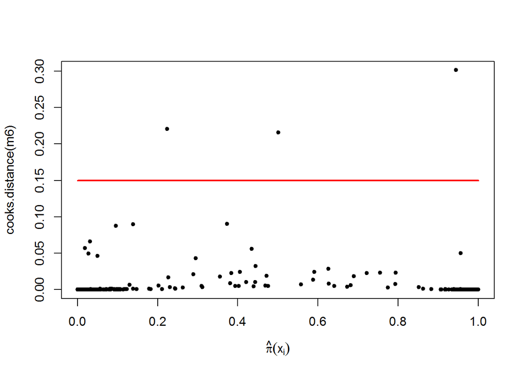

```
##
## Call:
## glm(formula = NSP ~ AC + UC + DP + ASTV + ALTV + Max + Nmax +
##     Mode + Variance + UC:Mode + UC:Variance, family = binomial(),
##     data = data2)
##
## Deviance Residuals:
##      Min        1Q    Median        3Q       Max
## -2.65722  -0.00761  -0.00025   0.00000   2.98866
##
## Coefficients:
##               Estimate Std. Error z value Pr(>|z|)
## (Intercept) -10.813327   4.180180  -2.587  0.00969 **
## AC           -2.537178   0.536058  -4.733 2.21e-06 ***
## UC            1.419444   1.089517   1.303  0.19264
## DP            4.813533   0.856289   5.621 1.89e-08 ***
## ASTV          0.176330   0.026868   6.563 5.28e-11 ***
## ALTV          0.077049   0.014265   5.401 6.61e-08 ***
## Max           0.045770   0.020216   2.264  0.02357 *
## Nmax         -0.364383   0.169513  -2.150  0.03159 *
## Mode         -0.066494   0.031056  -2.141  0.03226 *
## Variance      0.054304   0.028640   1.896  0.05795 .
## UC:Mode      -0.020061   0.008435  -2.378  0.01740 *
## UC:Variance   0.013045   0.005121   2.547  0.01086 *
## ---
## Signif. codes:  0 '***' 0.001 '**' 0.01 '*' 0.05 '.' 0.1 ' ' 1
##
## (Dispersion parameter for binomial family taken to be 1)
##
##     Null deviance: 1153.85  on 1827  degrees of freedom
## Residual deviance:  107.22  on 1816  degrees of freedom
## AIC: 131.22
##
## Number of Fisher Scoring iterations: 11
```

Сравнить полученные коэффициенты с коэффициентами модели, настроенной по полным данным:

```
##                 All data Filtered data
## (Intercept) -11.95841243  -10.81332715
## AC           -2.51400657   -2.53717817
## UC            1.41846677    1.41944430
## DP            4.52078373    4.81353261
## ASTV          0.17219295    0.17632958
## ALTV          0.07099096    0.07704926
## Max           0.04477817    0.04577046
## Nmax         -0.30817032   -0.36438256
## Mode         -0.05496894   -0.06649442
## Variance      0.04942089    0.05430361
## UC:Mode      -0.01917312   -0.02006094
## UC:Variance   0.01100584    0.01304476
```

Различия небольшие, так что оставим модель, настроенную на полных данных.

#### Итог

Посмотрим на качество классификации:

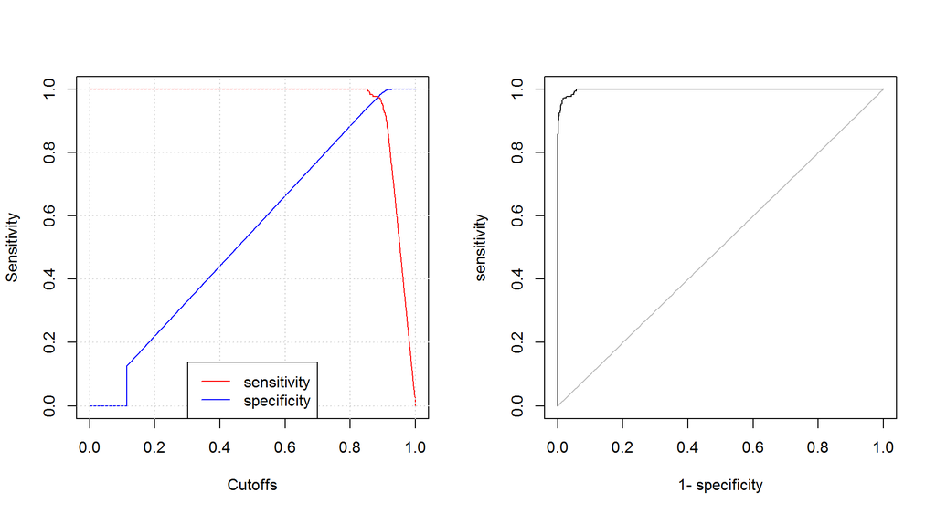

Приросты отношений шансов на патологию для каждого признака и доверительные интервалы для них:

```
##          AC          UC          DP        ASTV        ALTV         Max
##  0.08094328  4.13078212 91.90760047  1.18790702  1.07357152  1.04579584
##        Nmax        Mode    Variance     UC:Mode UC:Variance
##  0.73479016  0.94651455  1.05066247  0.98100951  1.01106663
```

```
##                   2.5 %      97.5 %
## AC           0.02712085   0.1969397
## UC           0.62995043  29.4001132
## DP          22.53020981 503.7756281
## ASTV         1.13564808   1.2551569
## ALTV         1.04861311   1.1037977
## Max          1.00622591   1.0868874
## Nmax         0.54124167   0.9747125
## Mode         0.89239876   1.0002110
## Variance     1.00532923   1.0993774
## UC:Mode      0.96603649   0.9950777
## UC:Variance  1.00327492   1.0199663
```

Расшифровки обозначений для признаков в финальной модели: - AC - число ускорений в секунду; - UC - число сокращений матки; - DP - число длительных замедлений в секунду; - ASTV - процент абнормальных краткосрочных изменений; - ALTV - процент абнормальных долгосрочных изменений; - Max - максимум гистограммы FHR; - Nmax - число раз, которое достигается максимум в гистограмме FHR; - Mode - мода гистограммы FHR; - Variance - дисперсия гистограммы FHR.